# Scikit-learn

```python
import numpy as np
import matplotlib as mpl
import matplotlib.pyplot as plt
import pandas as pd
import seaborn as sns
import missingno as mino
%matplotlib inline
```

## Load tidy-data

```python
iris = sns.load_dataset('iris')
```

```python
iris.info()
iris.describe(include='object')
```

```
<class 'pandas.core.frame.DataFrame'>
RangeIndex: 150 entries, 0 to 149
Data columns (total 5 columns):
sepal_length    150 non-null float64
sepal_width     150 non-null float64
petal_length    150 non-null float64
petal_width     150 non-null float64
species         150 non-null object
dtypes: float64(4), object(1)
memory usage: 5.9+ KB
```

|  | species |
| --- | --- |
| count | 150 |
| unique | 3 |
| top | setosa |
| freq | 50 |

```python
iris.sample(3)
```

|  | sepal_length | sepal_width | petal_length | petal_width | species |
| --- | --- | --- | --- | --- | --- |
| 120 | 6.9 | 3.2 | 5.7 | 2.3 | virginica |
| 91 | 6.1 | 3.0 | 4.6 | 1.4 | versicolor |
| 63 | 6.1 | 2.9 | 4.7 | 1.4 | versicolor |

```python
iris.head()
```

|  | sepal_length | sepal_width | petal_length | petal_width | species |
| --- | --- | --- | --- | --- | --- |
| 0 | 5.1 | 3.5 | 1.4 | 0.2 | setosa |
| 1 | 4.9 | 3.0 | 1.4 | 0.2 | setosa |
| 2 | 4.7 | 3.2 | 1.3 | 0.2 | setosa |
| 3 | 4.6 | 3.1 | 1.5 | 0.2 | setosa |
| 4 | 5.0 | 3.6 | 1.4 | 0.2 | setosa |

```python
iris.tail()
```

|  | sepal_length | sepal_width | petal_length | petal_width | species |
| --- | --- | --- | --- | --- | --- |
| 145 | 6.7 | 3.0 | 5.2 | 2.3 | virginica |
| 146 | 6.3 | 2.5 | 5.0 | 1.9 | virginica |
| 147 | 6.5 | 3.0 | 5.2 | 2.0 | virginica |
| 148 | 6.2 | 3.4 | 5.4 | 2.3 | virginica |
| 149 | 5.9 | 3.0 | 5.1 | 1.8 | virginica |

## Visualization

### Pairplot

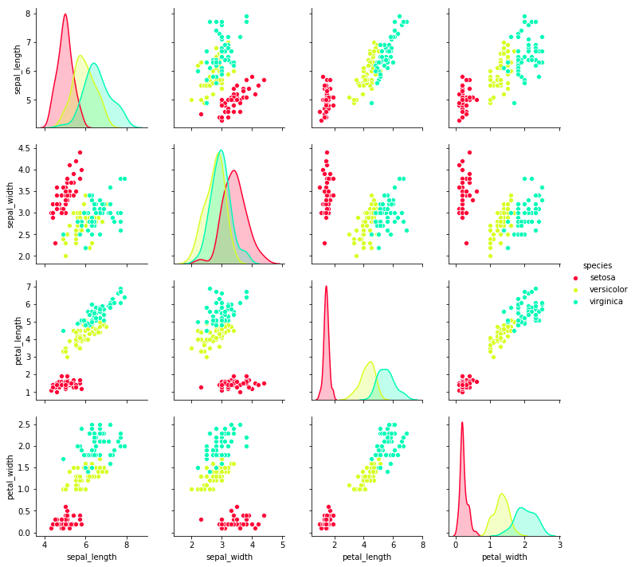

```python
sns.pairplot(iris, hue='species', palette='gist_ncar_r')
```

### Correlation

- https://en.wikipedia.org/wiki/Correlation_and_dependence

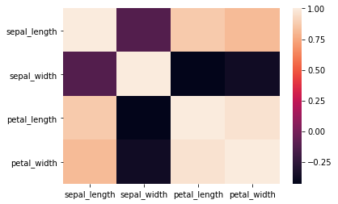

```python
sns.heatmap(iris.corr())
```

### Covariance

- https://en.wikipedia.org/wiki/Covariance

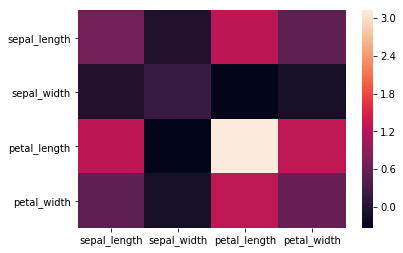

```python
sns.heatmap(iris.cov())
```

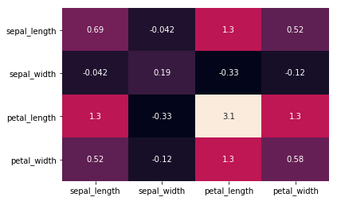

```python
sns.heatmap(iris.cov(), annot=True, cbar=False)
```

## Training

```python
from sklearn.neighbors import KNeighborsClassifier
# hold-out
from sklearn.model_selection import train_test_split
```

### Hold-out Cross Validation (Simple Cross Validation)

- S를 랜덤하게 S_train과 S_cv로 나눈다. S_train은 약 70%로 구성하여 모델 학습용으로 쓰고 나머지 S_cv는 평가용으로 쓴다.
- 각 모델 M_i을 S_train으로 학습시켜 hypothesis h_i를 구한다.
- S_cv(h_i)를 적용하였을때 error(generation error)를 최소로 하는 모델을 선택한다.
- 옵션으로, 모델을 선택후 그 모델에 S_cv도 추가로 학습시킨다.
- 이 방식의 단점은 빼놓은 30%의 데이터를 학습 및 평가에 반영하지 않는다는 것이다.
- 또한 상황에 따라 편향된 결과를 나타낼 수도 있다.
- 그리고 0.7(70%)가 보편적이긴 하지만 데이터에 따라 부적절할 수 있다.

```python
X, y = iris.iloc[:, :-1], iris.iloc[:, -1]
```

```python
X_train, X_test, y_train, y_test = train_test_split(X, y)
len(X_train), len(X_test), len(y_train), len(y_test)
```

```
(112, 38, 112, 38)
```

```python
# training data와 test data를 각각 75%, 25%의 비율로 나눈다.
round(len(X_train) / len(X), 2), round(len(X_test) / len(X), 2)
```

```
(0.75, 0.25)
```

```python
knn = KNeighborsClassifier()
knn.fit(X_train, y_train)
knn.score(X_test, y_test)
```

```
0.9210526315789473
```

```python
knn.predict_proba([[3, 3, 3, 3], [3, 3, 1, 3], [3, 3, 3, 1]])
```

```
array([[0. , 1. , 0. ],
       [1. , 0. , 0. ],
       [0.2, 0.8, 0. ]])
```

```python
# Hyper-parameter를 바꿔주며 성능이 좋은 모델을 선택해본다.
for n in range(1, 10+1):
    knn = KNeighborsClassifier(n_neighbors=n)
    knn.fit(X_train, y_train)
    print(knn.score(X_test, y_test))
```

```
0.9210526315789473
0.9210526315789473
0.9210526315789473
0.9210526315789473
0.9210526315789473
0.9473684210526315
0.8947368421052632
0.9210526315789473
0.9210526315789473
0.9210526315789473
```

## Model evaluation

```python
from sklearn.metrics import confusion_matrix
```

```python
# confusion_matrix의 내부 구현은 다음과 같이 구현되어있다.
import inspect
print(inspect.getsource(confusion_matrix))
```

[output not shown]

[output cut: 53 more lines]

[output not shown]

## Confusion matrix

- https://en.wikipedia.org/wiki/Confusion_matrix
- 다음 4가지를 기준으로 TPR, TNR, PPV, NPV, FNR, FPR, FDR, FOR를 평가한다.
  - True Positive (TP): 참인 것을 참이라고 맞춘 경우 (정답)
  - True Negative (TN): 거짓인 것을 거짓이라고 맞춘 경우 (정답)
  - False Positive (FP): 참인 것을 거짓이라고 맞춘 경우 (오답)
  - False Negative (FN): 거짓인 것을 참이라고 맞춘 경우 (오답)
- Precision: TP / TP + FP (참이라고 예측한 것 중에서 실제로도 참인 것. 즉, 푼 문제 중 맞춘 개수)
- Recall(sensitivity): TP / TP + FN (실제로 참인 것 중 참이라고 예측한 것. 즉, 전체 중 맞춘 개수)
- Accuracy: TP + TN / TP + TN + FP + FN (전체 중에서 올바르게 예측한 것)

```python
CM = confusion_matrix(y_test, knn.predict(X_test))
CM
```

```
array([[12,  0,  0],
       [ 0, 10,  2],
       [ 0,  1, 13]])
```

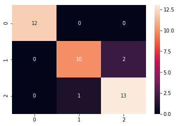

```python
sns.heatmap(CM, annot=True)
```

## 난수 생성 관련

- https://docs.python.org/3/library/random.html

```python
import random
```

```python
dir(random)
```

```
['BPF',
 'LOG4',
 'NV_MAGICCONST',
 'RECIP_BPF',
 'Random',
 'SG_MAGICCONST',
 'SystemRandom',
 'TWOPI',
 '_BuiltinMethodType',
 '_MethodType',
 '_Sequence',
 '_Set',
 '__all__',
 '__builtins__',
 '__cached__',
 '__doc__',
 '__file__',
 '__loader__',
 '__name__',
 '__package__',
 '__spec__',
 '_acos',
 '_bisect',
 '_ceil',
 '_cos',
 '_e',
 '_exp',
 '_inst',
 '_itertools',
 '_log',
 '_pi',
 '_random',
 '_sha512',
 '_sin',
 '_sqrt',
 '_test',
 '_test_generator',
 '_urandom',
 '_warn',
 'betavariate',
 'choice',
 'choices',
 'expovariate',
 'gammavariate',
 'gauss',
 'getrandbits',
 'getstate',
 'lognormvariate',
 'normalvariate',
 'paretovariate',
 'randint',
 'random',
 'randrange',
 'sample',
 'seed',
 'setstate',
 'shuffle',
 'triangular',
 'uniform',
 'vonmisesvariate',
 'weibullvariate']
```

### random.seed(a=None, version=2)

- 난수 생성에 대한 초기화 작업
- 재현 가능성을 보장하며 일정한 순서대로 난수가 발생됨
- a는 정수 타입이 올 수 있으며 생략 가능하다.
- a를 생략할 경우 현재 시스템 시간을 사용한다.

```python
random.seed(1)
```

### random.random()

- 0.0부터 1.0까지의 무작위 부동 소수점을 반환한다.

```python
random.random()
```

```
0.13436424411240122
```

### random.uniform(a, b)

- a <= b를 만족할 때, a <= N <= b를,
- b < a를 만족할 때, b <= N <= a에 만족하는 부동 소수점을 반환한다.

```python
random.uniform(2, 3)
```

```
2.8474337369372327
```

### random.shuffle(x[, random])

- x의 순서를 임의로 섞는다.

```python
x = [1, 2, 3, 4, 5]
random.shuffle(x)
x
```

```
[4, 2, 5, 3, 1]
```

### random.sample(population, k)

- population에서 k개 만큼 무작위로 뽑아 반환한다.

```python
x = [1, 2, 3, 4, 5]
random.sample(x, 3)
```

```
[4, 5, 3]
```

### Factorial and Binomial distribution

```python
@np.vectorize
def factorial(n):
    """Calculates the factorial of `n`
    """
    vals = list(range(1, n + 1))
    if len(vals) <= 0:
        return 1

    prod = 1
    for val in vals:
        prod *= val

    return prod


def n_choose_k(n, k):
    """Calculates the binomial coefficient
    """
    return factorial(n) / (factorial(k) * factorial(n - k))


def binom_prob(n, k, p):
    """Returns the probability of see `k` heads in `n` coin tosses

    Arguments:

    n - number of trials
    k - number of trials in which an event took place
    p - probability of an event happening

    """
    return n_choose_k(n, k) * p**k * (1 - p)**(n - k)
```

```python
n, k, p = 5, 3, 0.4
```

```python
factorial(n)
```

```
array(120)
```

```python
n_choose_k(n, k)
```

```
10.0
```

```python
binom_prob(n, k, p)
```

```
0.23040000000000005
```

# Scipy

- https://docs.scipy.org/doc/scipy/reference/?v=20190408205922

```python
# 에러 메시지 감춤
import warnings
warnings.filterwarnings('ignore')
```

### Factorial and Binomial distribution

```python
from scipy.misc import factorial
```

```python
factorial(n)
```

```
array(120.)
```

```python
from scipy.misc import comb
```

```python
comb(n, k)
```

```
10.0
```

```python
from scipy.stats import binom
```

```python
rv = binom(n, p)
rv
```

```
<scipy.stats._distn_infrastructure.rv_frozen at 0x7f4da41d8ac8>
```

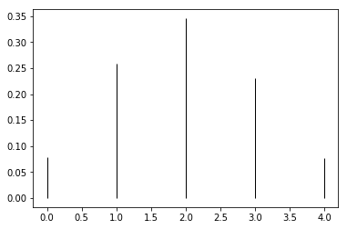

```python
x = np.arange(binom.ppf(0.01, n, p), binom.ppf(0.99, n, p))
fig, ax = plt.subplots(1, 1)
ax.vlines(
    x,
    0,
    rv.pmf(x),
    colors='k',
    linestyles='-',
    lw=1,
)
plt.show()
```